# EDA Research - Sec10K Filings v1.1

### EDA Notebook - Sec Filings 10-K Dataset.

```
- Start date; mid-september.
- Code notebook author & owner - Joel Markapudi
```

#### Plan for notebook EDA: (potentially)

1. Schema of dataset ovevrview, Column overview, etc.
2. Company stats, Temporal coverage/stats (yearly filings, etc.), Sentence Distribution stats.
3. Section Mapping & Distribution, Section breakdown, Text by Section stats, Common N-Grams (Top 20) ??
4. Missing data, Missing data patterns, Cardinality analysis. (heatmaps, etc.)
5. Data Quality flags, Edge cases.

### High level plan for now.

```
     [HF datasets] → [Ingest/Cache] → [Chunk+Metadata] → [Embed] → [Index]
                                             |                 ↑
                                             v                 |
                                        [Query Router] → [Retrieve]
                                             |                 |
                                             v                 v
                                   [Structured Extractor]  [Summarizer]
                                             |                 |
                                             └───[Normalizer/Validator]───┘
                                                       |
                                                  [Fusion & Cache]
                                                       |
                                                  [Report/API]
```

```python
# Notebook bootstrap
from pathlib import Path
import sys, os

# point Python to your ./src so `import` works
PROJECT_ROOT = Path.cwd().resolve()
SRC = PROJECT_ROOT / "src"
if str(SRC) not in sys.path:
    sys.path.insert(0, str(SRC))

# env vars (reads assets/config.env you already have)
from dotenv import load_dotenv
load_dotenv(PROJECT_ROOT / "assets" / "config.env")

# autoreload so edits in src/ reflect without restarting kernel
%load_ext autoreload
%autoreload 2
```

```
The autoreload extension is already loaded. To reload it, use:
  %reload_ext autoreload
```

```python
import nltk
nltk.download('punkt')       # Sentence tokenizer
nltk.download('stopwords')   # English stopwords
nltk.download('averaged_perceptron_tagger')  # POS tagging (optional)
```

```
True
```

```python
## Starting all EDA:

# ============================================================================
# Section 1: Data Understanding - SEC 10-K Filings Dataset

import pandas as pd
import polars as pl
import numpy as np
import seaborn as sns
import matplotlib.pyplot as plt
from pathlib import Path
from itables import init_notebook_mode, show
import warnings
from IPython.display import display, HTML


# warnings.filterwarnings('ignore')
# init_notebook_mode(all_interactive=True)

# sns.set_style("whitegrid")
# plt.rcParams['figure.figsize'] = (12, 6)
# plt.rcParams['font.size'] = 11


# # Polars display settings (show ALL columns, no truncation)
# pl.Config.set_tbl_width_chars(1000)
# pl.Config.set_tbl_cols(-1)  # -1 means show ALL columns
# pl.Config.set_tbl_rows(100)  # Show up to 100 rows when printing

# # Pandas display settings (for later use)
# pd.set_option('display.max_columns', None)
# pd.set_option('display.max_colwidth', 100)
# pd.set_option('display.precision', 2)


def display_table_with_html(df, title=""):
    """Display pandas DataFrame as styled HTML table"""
    display(HTML(f"<h3>{title}</h3>"))
    html_str = df.to_html(classes='table table-striped table-hover', border=0)
    display(HTML(html_str))


print("Environment ready")


# Load dataset
DATA_PATH = Path("../data/exports/sec_filings_small_full.parquet")
df = pl.read_parquet(DATA_PATH)

print(f"Dataset loaded: {df.shape[0]:,} rows × {df.shape[1]} columns")
print(f"Memory usage: {df.estimated_size('mb'):.1f} MB")
```

```
Environment ready
Dataset loaded: 200,000 rows × 19 columns
Memory usage: 144.1 MB
```

```python
display_table_with_html(
    df.head(3).to_pandas(),
    title="Dataset Preview (First 3 Rows)"
)
```

Dataset Preview (First 3 Rows)

|  | cik | sentence | section | labels | filingDate | name | docID | sentenceID | sentenceCount | tickers | exchanges | entityType | sic | stateOfIncorporation | tickerCount | acceptanceDateTime | form | reportDate | returns |
| --- | --- | --- | --- | --- | --- | --- | --- | --- | --- | --- | --- | --- | --- | --- | --- | --- | --- | --- | --- |
| 0 | 0000001750 | ITEM 1.BUSINESS General AAR CORP. and its subsidiaries are referred to herein collectively as “AAR,” “Company,” “we,” “us,” and “our” unless the context indicates otherwise. | 0 | {'1d': 0, '30d': 0, '5d': 1} | 2020-07-21 | AAR CORP | 0000001750_10-K_2020 | 0000001750_10-K_2020_section_1_0 | 1 | [AIR] | [NYSE] | operating | 3720 | DE | 1 | 2020-07-21T17:19:15.000Z | 10-K | 2020-05-31 | {'1d': {'closePriceEndDate': 19.010000228881836, 'closePriceStartDate': 18.190000534057617, 'endDate': '2020-07-22T00:00:00-04:00', 'ret': 0.04507969692349434, 'startDate': '2020-07-20T00:00:00-04:00'… |
| 1 | 0000001750 | AAR was founded in 1951, organized in 1955 and reincorporated in Delaware in 1966. | 0 | {'1d': 0, '30d': 0, '5d': 1} | 2020-07-21 | AAR CORP | 0000001750_10-K_2020 | 0000001750_10-K_2020_section_1_1 | 2 | [AIR] | [NYSE] | operating | 3720 | DE | 1 | 2020-07-21T17:19:15.000Z | 10-K | 2020-05-31 | {'1d': {'closePriceEndDate': 19.010000228881836, 'closePriceStartDate': 18.190000534057617, 'endDate': '2020-07-22T00:00:00-04:00', 'ret': 0.04507969692349434, 'startDate': '2020-07-20T00:00:00-04:00'… |
| 2 | 0000001750 | We are a diversified provider of products and services to the worldwide aviation and government and defense markets. | 0 | {'1d': 0, '30d': 0, '5d': 1} | 2020-07-21 | AAR CORP | 0000001750_10-K_2020 | 0000001750_10-K_2020_section_1_2 | 3 | [AIR] | [NYSE] | operating | 3720 | DE | 1 | 2020-07-21T17:19:15.000Z | 10-K | 2020-05-31 | {'1d': {'closePriceEndDate': 19.010000228881836, 'closePriceStartDate': 18.190000534057617, 'endDate': '2020-07-22T00:00:00-04:00', 'ret': 0.04507969692349434, 'startDate': '2020-07-20T00:00:00-04:00'… |

### First View Analysis On Content:

Three columns contain nested JSON/dict structures:

```
Column          Structure                               Content
labels          {'1d': 0, '30d': 0, '5d': 1}        Binary classification targets (market movement?)
returns         Nested dict with 1d/5d/30d keys     Stock price data: closePriceStartDate, closePriceEndDate,
                                                    ret (return %), date
tickers         [AIR]                               List of ticker symbols
```

1. These are ML targets. Cannot directly store these in Qdrant payload (need flattening)
2. Tickers list: Understand this better, soon.

```
Row 0: "ITEM 1.BUSINESS General AAR CORP. and its subsidiaries..." (180 chars)
Row 1: "AAR was founded in 1951, organized in 1955..." (84 chars)
Row 2: "We are a diversified provider of products..." (121 chars)
```

1. Sentences are coherent, complete thoughts.

```
"ITEM 1.BUSINESS General AAR CORP. and its subsidiaries are referred to..."
 └──────────────┘
   This part
```

- The text itself starts with "ITEM 1.BUSINESS" as part of the sentence content. It's not in a separate column - it's embedded in the sentence text.
- Are cik, section, reportDate actually useful for filtering? (Do they have good distribution?)
- Are there other patterns we haven't discovered yet?

```python
# Table 1: Complete schema with statistics
schema_info = []

for col in df.columns:
    dtype = str(df[col].dtype)
    null_count = df[col].null_count()
    null_pct = (null_count / len(df)) * 100
    unique_count = df[col].n_unique()

    try:
        if df[col].dtype == pl.List(pl.Utf8):
            sample = str(df[col].drop_nulls().head(1).to_list()[0][:2]) + "..."
        else:
            sample = str(df[col].drop_nulls().head(1).to_list()[0])
            if len(sample) > 50:
                sample = sample[:47] + "..."
    except:
        sample = "N/A"

    schema_info.append({
        'Column': col,
        'Type': dtype,
        'Nulls': f"{null_count:,}",
        'Null %': f"{null_pct:.1f}%",
        'Unique': f"{unique_count:,}",
        'Sample': sample
    })

schema_df = pd.DataFrame(schema_info)

display_table_with_html( schema_df, title="Table 1: Full Schema Overview (19 Columns)" )
```

Table 1: Full Schema Overview (19 Columns)

|  | Column | Type | Nulls | Null % | Unique | Sample |
| --- | --- | --- | --- | --- | --- | --- |
| 0 | cik | String | 0 | 0.0% | 10 | 0000001750 |
| 1 | sentence | String | 0 | 0.0% | 96,465 | ITEM 1.BUSINESS General AAR CORP. and its subsi... |
| 2 | section | Int64 | 0 | 0.0% | 20 | 0 |
| 3 | labels | Struct({'1d': Int64, '30d': Int64, '5d': Int64}) | 0 | 0.0% | 8 | {'1d': 0, '30d': 0, '5d': 1} |
| 4 | filingDate | String | 0 | 0.0% | 181 | 2020-07-21 |
| 5 | name | String | 0 | 0.0% | 10 | AAR CORP |
| 6 | docID | String | 0 | 0.0% | 188 | 0000001750_10-K_2020 |
| 7 | sentenceID | String | 0 | 0.0% | 200,000 | 0000001750_10-K_2020_section_1_0 |
| 8 | sentenceCount | Int64 | 0 | 0.0% | 200,000 | 1 |
| 9 | tickers | List(String) | 0 | 0.0% | 10 | ['AIR']... |
| 10 | exchanges | List(String) | 0 | 0.0% | 3 | ['NYSE']... |
| 11 | entityType | String | 0 | 0.0% | 1 | operating |
| 12 | sic | String | 0 | 0.0% | 10 | 3720 |
| 13 | stateOfIncorporation | String | 0 | 0.0% | 5 | DE |
| 14 | tickerCount | Int32 | 0 | 0.0% | 1 | 1 |
| 15 | acceptanceDateTime | String | 0 | 0.0% | 188 | 2020-07-21T17:19:15.000Z |
| 16 | form | String | 0 | 0.0% | 1 | 10-K |
| 17 | reportDate | String | 0 | 0.0% | 91 | 2020-05-31 |
| 18 | returns | Struct({'1d': Struct({'closePriceEndDate': Float64, 'closePriceStartDate': Float64, 'endDate': String, 'ret': Float64, 'startDate': String}), '30d': Struct({'closePriceEndDate': Float64, 'closePriceSt… | 0 | 0.0% | 188 | {'1d': {'closePriceEndDate': 19.010000228881836... |

```python
# Table 2: Logical grouping of columns by purpose
categories = {
    '🔑 Identifiers': ['cik', 'docID', 'sentenceID', 'name', 'tickers'],
    '📝 Text Content': ['sentence'],
    '📊 Document Metadata': ['section', 'filingDate', 'reportDate', 'period', 'form', 'acceptanceDateTime'],
    '🏢 Company Info': ['exchanges', 'entityType', 'sic', 'stateOfIncorporation', 'tickerCount'],
    '🎯 ML Targets': ['labels', 'returns'],
    '📈 Derived/Counters': ['sentenceCount']
}

# Build summary table
cat_summary = []
for category, cols in categories.items():
    for col in cols:
        if col in df.columns:
            dtype = str(df[col].dtype)
            null_pct = (df[col].null_count() / len(df)) * 100
            unique = df[col].n_unique()

            cat_summary.append({
                'Category': category,
                'Column': col,
                'Type': dtype,
                'Null %': f"{null_pct:.1f}%",
                'Unique': f"{unique:,}"
            })

cat_df = pd.DataFrame(cat_summary)

display_table_with_html(
    cat_df,
    title="Table 2: Column Categorization by Purpose"
)
```

Table 2: Column Categorization by Purpose

|  | Category | Column | Type | Null % | Unique |
| --- | --- | --- | --- | --- | --- |
| 0 | 🔑 Identifiers | cik | String | 0.0% | 10 |
| 1 | 🔑 Identifiers | docID | String | 0.0% | 188 |
| 2 | 🔑 Identifiers | sentenceID | String | 0.0% | 200,000 |
| 3 | 🔑 Identifiers | name | String | 0.0% | 10 |
| 4 | 🔑 Identifiers | tickers | List(String) | 0.0% | 10 |
| 5 | 📝 Text Content | sentence | String | 0.0% | 96,465 |
| 6 | 📊 Document Metadata | section | Int64 | 0.0% | 20 |
| 7 | 📊 Document Metadata | filingDate | String | 0.0% | 181 |
| 8 | 📊 Document Metadata | reportDate | String | 0.0% | 91 |
| 9 | 📊 Document Metadata | form | String | 0.0% | 1 |
| 10 | 📊 Document Metadata | acceptanceDateTime | String | 0.0% | 188 |
| 11 | 🏢 Company Info | exchanges | List(String) | 0.0% | 3 |
| 12 | 🏢 Company Info | entityType | String | 0.0% | 1 |
| 13 | 🏢 Company Info | sic | String | 0.0% | 10 |
| 14 | 🏢 Company Info | stateOfIncorporation | String | 0.0% | 5 |
| 15 | 🏢 Company Info | tickerCount | Int32 | 0.0% | 1 |
| 16 | 🎯 ML Targets | labels | Struct({'1d': Int64, '30d': Int64, '5d': Int64}) | 0.0% | 8 |
| 17 | 🎯 ML Targets | returns | Struct({'1d': Struct({'closePriceEndDate': Float64, 'closePriceStartDate': Float64, 'endDate': String, 'ret': Float64, 'startDate': String}), '30d': Struct({'closePriceEndDate': Float64, 'closePriceSt… | 0.0% | 188 |
| 18 | 📈 Derived/Counters | sentenceCount | Int64 | 0.0% | 200,000 |

- Expected: 10 sections (0-9 for 10-K items)
- Actual: section has 20 unique values
  - What this means:
  - Either sections go beyond 0-9 (10-19 range?)
  - OR there are sub-sections (e.g., 1.1, 1.2 encoded as 11, 12?)

```
Field	    Unique Values	    Interpretation	                Filtering Value
cik	        10	                10 companies only	            ✅ HIGH - company filter
name	    10	                1:1 with CIK	                ✅ HIGH - display name
tickers	    10	                1:1 with company	            ✅ HIGH - user-friendly filter
section	    20	                ⚠️ MORE than expected	        ✅ HIGH - but needs mapping
docID	    188	                ~19 docs/company	            ✅ MEDIUM - document-level filter
filingDate	181	                Nearly 1:1 with docID	        ⚠️ LOW - use reportDate instead
reportDate	91	                ~2 filings/period	            ✅ MEDIUM - time filter
sentence	96,465	            48% unique	                    ❌ N/A - this is the content
sentenceID	200,000	            100% unique	                    ✅ HIGH - primary key
```

- 188 documents total across 10 companies:
  - Average: 18.8 documents per company
  - This suggests ~19 years of filings (if annual 10-Ks)
- 91 unique reportDates vs 181 filingDates:
  - Multiple companies share same fiscal year-ends
  - Common fiscal year-ends: Dec 31, Jun 30, Sep 30
  - filingDate spread (181 unique) = different filing times
- Three binary sentiment labels (1d, 5d, 30d) derived from market reaction windows.
- Potential supervised target for finetuning sentiment or volatility predictors.
- Label-conditioned embeddings: correlate language tone with short-term market moves.
- Later: contrastive training of “risk-positive vs risk-negative” sentences.

#### Metadata Richness:

- can enrich embeddings with these categorical tags (via adapters or metadata vectors).
- these features are extremely useful for metadata-filtered search and bias analysis later.

#### Text Content Insights

- 96,465 unique sentences out of 200,000 total:
  - Duplication rate: 51.7% (103,535 repeated sentences)
  - This is NORMAL for 10-Ks because:
    - Boilerplate language (risk disclaimers, accounting policies)
    - Repeated across years ("We are incorporated in Delaware...")
    - Standard regulatory phrases

For RAG:

- Duplicates are FINE (same sentence, different context/year)
- Embeddings will cluster similar content

#### Low-value fields (don't change, not useful for filtering):

```
Field                   Unique      Why Low Value
entityType              1           Always "operating" (no variance)
tickerCount             1           Always 1 ticker (derived field)
form                    1           Always "10-K" (dataset definition)
exchanges               3           Only 3 exchanges (NYSE, NASDAQ, ?) - low filtering value
stateOfIncorporation    5           Only 5 states (mostly DE) - not relevant for financial analysis
```

Medium-value field:

```
Field                   Unique      Potential Uses
sic10                   10          Industry codes (1:1 with company, but useful for "show me tech companies")
```

#### ML Target Fields (Finance-Specific)

- labels structure: {'1d': 0, '30d': 0, '5d': 1}
- Binary classification: Did stock go UP (1) or DOWN/FLAT (0)?
- Timeframes: 1-day, 5-day, 30-day post-filing
- 8 unique combinations = all possible 0/1 patterns (2³ = 8)
- returns structure: Nested price data
- 188 unique values = 1 per document (document-level targets, not sentence-level)
- Contains: start/end prices, return %, dates
- Used for regression tasks (predict magnitude of movement)

#### Temporal Metadata Analysis

Three timestamp fields:

```
Field               Unique        Granularity        Use Case
reportDate          91            Fiscal period end  ✅ "Show me Q4 2019 results"
filingDate          181           SEC filing date    ⚠️ "When did market learn this?"
acceptanceDateTime  188           Exact timestamp    ❌ Too granular (hour/minute irrelevant)
```

- Why reportDate (91) < filingDate (181)?
- Multiple companies file on same calendar date (e.g., 2020-02-28)
- But their fiscal year-ends differ (some Dec 31, some Jan 31, some custom)
- ❌ labels, returns (ML targets)
- ❌ entityType, tickerCount, form (no variance)
- ❌ exchanges, stateOfIncorporation (low value)
- ❌ acceptanceDateTime (too granular)
- ❌ sentenceCount (internal counter)

#### Chunking:

[output not shown]

```python
# Answer Q2: Company distribution balance
company_stats = (
    df.group_by("cik", "name")
    .agg([
        pl.count("sentence").alias("sentence_count"),
        pl.col("tickers").first().alias("tickers"),
        pl.col("sic").first().alias("sic"),
        pl.n_unique("docID").alias("num_filings"),
        pl.col("reportDate").min().alias("earliest_report"),
        pl.col("reportDate").max().alias("latest_report"),
    ])
    .sort("sentence_count", descending=True)
)

# Convert to pandas for display
company_stats_pd = company_stats.to_pandas()

# Extract first ticker from list (clean display)
company_stats_pd['ticker'] = company_stats_pd['tickers'].apply(lambda x: x[0] if isinstance(x, list) and len(x) > 0 else 'N/A')
company_stats_pd = company_stats_pd.drop(columns=['tickers'])

# Reorder columns for clarity
company_stats_pd = company_stats_pd[['cik', 'name', 'ticker', 'sic', 'sentence_count', 'num_filings', 'earliest_report', 'latest_report']]

display_table_with_html(
    company_stats_pd,
    title="Table 3: Company Statistics (Answers Q2: Distribution Balance)"
)

# Quick summary
total_sentences = company_stats_pd['sentence_count'].sum()
avg_sentences = company_stats_pd['sentence_count'].mean()
std_sentences = company_stats_pd['sentence_count'].std()

print(f"\n📊 Distribution Summary:")
print(f"   Total sentences: {total_sentences:,}")
print(f"   Average per company: {avg_sentences:,.0f}")
print(f"   Std deviation: {std_sentences:,.0f}")
print(f"   Imbalance ratio: {company_stats_pd['sentence_count'].max() / company_stats_pd['sentence_count'].min():.2f}x (max/min)")
```

Table 3: Company Statistics (Answers Q2: Distribution Balance)

|  | cik | name | ticker | sic | sentence_count | num_filings | earliest_report | latest_report |
| --- | --- | --- | --- | --- | --- | --- | --- | --- |
| 0 | 0000002488 | ADVANCED MICRO DEVICES INC | N/A | 3674 | 38799 | 24 | 1993-12-26 | 2020-12-26 |
| 1 | 0000001800 | ABBOTT LABORATORIES | N/A | 2834 | 30554 | 25 | 1993-12-31 | 2020-12-31 |
| 2 | 0000002969 | Air Products & Chemicals, Inc. | N/A | 2810 | 26282 | 20 | 2001-09-30 | 2020-09-30 |
| 3 | 0000003197 | CECO ENVIRONMENTAL CORP | N/A | 3564 | 24867 | 17 | 2004-12-31 | 2020-12-31 |
| 4 | 0000001750 | AAR CORP | N/A | 3720 | 20350 | 21 | 1994-05-31 | 2020-05-31 |
| 5 | 0000002186 | BK Technologies Corp | N/A | 3663 | 19081 | 21 | 1995-12-31 | 2020-12-31 |
| 6 | 0000002098 | ACME UNITED CORP | N/A | 3420 | 15849 | 26 | 1995-12-31 | 2020-12-31 |
| 7 | 0000002178 | ADAMS RESOURCES & ENERGY, INC. | N/A | 5172 | 14964 | 19 | 2002-12-31 | 2020-12-31 |
| 8 | 0000001961 | WORLDS INC | N/A | 7372 | 7797 | 13 | 2008-12-31 | 2020-12-31 |
| 9 | 0000003453 | Matson, Inc. | N/A | 4400 | 1457 | 2 | 2019-12-31 | 2020-12-31 |

```
📊 Distribution Summary:
   Total sentences: 200,000
   Average per company: 20,000
   Std deviation: 10,874
   Imbalance ratio: 26.63x (max/min)
```

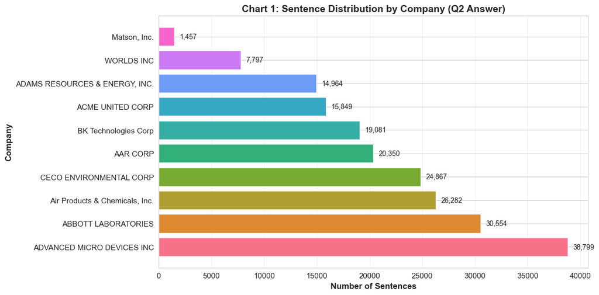

```python
# Visualize company balance (bar chart)
fig, ax = plt.subplots(figsize=(12, 6))

companies = company_stats_pd['name'].tolist()
counts = company_stats_pd['sentence_count'].tolist()

bars = ax.barh(companies, counts, color=sns.color_palette("husl", 10))
ax.set_xlabel('Number of Sentences', fontsize=12, fontweight='bold')
ax.set_ylabel('Company', fontsize=12, fontweight='bold')
ax.set_title('Chart 1: Sentence Distribution by Company (Q2 Answer)', fontsize=14, fontweight='bold')
ax.grid(axis='x', alpha=0.3)

# Add value labels on bars
for i, (bar, count) in enumerate(zip(bars, counts)):
    ax.text(count + 500, bar.get_y() + bar.get_height()/2,
            f'{count:,}', va='center', fontsize=10)

plt.tight_layout()
plt.show()
```

```python
# Answer Q3: Temporal distribution
# Extract year from reportDate
df_temporal = df.with_columns([
    pl.col("reportDate").str.strptime(pl.Date, "%Y-%m-%d").alias("report_date_parsed")
]).with_columns([
    pl.col("report_date_parsed").dt.year().alias("year")
])

# Sentences per year
year_stats = (
    df_temporal.group_by("year")
    .agg([
        pl.count("sentence").alias("sentence_count"),
        pl.n_unique("docID").alias("num_filings")
    ])
    .sort("year")
)

year_stats_pd = year_stats.to_pandas()

display_table_with_html(
    year_stats_pd,
    title="Table 4: Temporal Distribution by Year (Answers Q3: Date Range)"
)

# Summary stats
print(f"\n📅 Temporal Coverage:")
print(f"   Earliest year: {year_stats_pd['year'].min()}")
print(f"   Latest year: {year_stats_pd['year'].max()}")
print(f"   Total span: {year_stats_pd['year'].max() - year_stats_pd['year'].min() + 1} years")
print(f"   Average sentences/year: {year_stats_pd['sentence_count'].mean():,.0f}")
```

Table 4: Temporal Distribution by Year (Answers Q3: Date Range)

|  | year | sentence_count | num_filings |
| --- | --- | --- | --- |
| 0 | 1993 | 853 | 2 |
| 1 | 1994 | 1257 | 3 |
| 2 | 1995 | 1135 | 3 |
| 3 | 1996 | 1211 | 3 |
| 4 | 1997 | 1510 | 3 |
| 5 | 1998 | 1365 | 3 |
| 6 | 1999 | 370 | 1 |
| 7 | 2000 | 1181 | 2 |
| 8 | 2001 | 1298 | 3 |
| 9 | 2002 | 6361 | 7 |
| 10 | 2003 | 6631 | 7 |
| 11 | 2004 | 7878 | 8 |
| 12 | 2005 | 8290 | 8 |
| 13 | 2006 | 9637 | 8 |
| 14 | 2007 | 9916 | 8 |
| 15 | 2008 | 9929 | 9 |
| 16 | 2009 | 10473 | 9 |
| 17 | 2010 | 10511 | 9 |
| 18 | 2011 | 10879 | 9 |
| 19 | 2012 | 9976 | 9 |
| 20 | 2013 | 9713 | 9 |
| 21 | 2014 | 10228 | 9 |
| 22 | 2015 | 10572 | 9 |
| 23 | 2016 | 11251 | 9 |
| 24 | 2017 | 11990 | 9 |
| 25 | 2018 | 11956 | 9 |
| 26 | 2019 | 11034 | 10 |
| 27 | 2020 | 12595 | 10 |

```
📅 Temporal Coverage:
   Earliest year: 1993
   Latest year: 2020
   Total span: 28 years
   Average sentences/year: 7,143
```

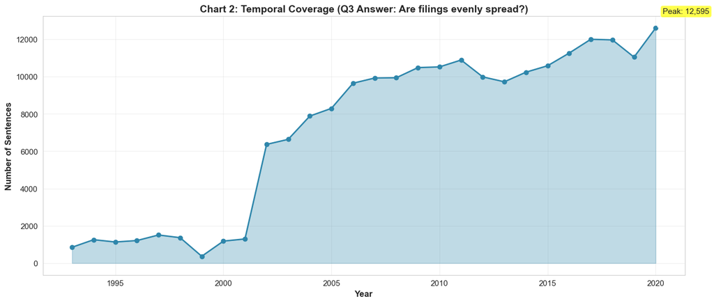

```python
# Chart 2: Sentences over time
fig, ax = plt.subplots(figsize=(14, 6))

years = year_stats_pd['year'].tolist()
counts = year_stats_pd['sentence_count'].tolist()

ax.plot(years, counts, marker='o', linewidth=2, markersize=6, color='#2E86AB')
ax.fill_between(years, counts, alpha=0.3, color='#2E86AB')

ax.set_xlabel('Year', fontsize=12, fontweight='bold')
ax.set_ylabel('Number of Sentences', fontsize=12, fontweight='bold')
ax.set_title('Chart 2: Temporal Coverage (Q3 Answer: Are filings evenly spread?)', fontsize=14, fontweight='bold')
ax.grid(True, alpha=0.3)

# Add annotations for min/max years
max_idx = counts.index(max(counts))
min_idx = counts.index(min(counts))
ax.annotate(f'Peak: {max(counts):,}', xy=(years[max_idx], counts[max_idx]),
            xytext=(10, 20), textcoords='offset points',
            bbox=dict(boxstyle='round', fc='yellow', alpha=0.7),
            arrowprops=dict(arrowstyle='->', connectionstyle='arc3,rad=0'))

plt.tight_layout()
plt.show()
```

```python
# Answer Q1: What are the 20 section codes?
section_stats = (
    df.group_by("section")
    .agg([
        pl.count("sentence").alias("sentence_count"),
        pl.n_unique("cik").alias("num_companies")
    ])
    .sort("section")
)

section_stats_pd = section_stats.to_pandas()

# Add percentage
section_stats_pd['percentage'] = (section_stats_pd['sentence_count'] / len(df) * 100).round(2)

display_table_with_html(
    section_stats_pd,
    title="Table 5: Section Code Distribution (Answers Q1: What are the 20 codes?)"
)

print(f"\n🔍 Section Analysis:")
print(f"   Expected sections: 0-9 (10 codes)")
print(f"   Actual sections: {section_stats_pd['section'].min()} to {section_stats_pd['section'].max()} ({len(section_stats_pd)} codes)")
print(f"   Section coverage: {section_stats_pd['num_companies'].min()}-{section_stats_pd['num_companies'].max()} companies per section")
```

Table 5: Section Code Distribution (Answers Q1: What are the 20 codes?)

|  | section | sentence_count | num_companies | percentage |
| --- | --- | --- | --- | --- |
| 0 | 0 | 21311 | 9 | 10.66 |
| 1 | 1 | 24627 | 10 | 12.31 |
| 2 | 2 | 374 | 9 | 0.19 |
| 3 | 3 | 2317 | 9 | 1.16 |
| 4 | 4 | 4534 | 10 | 2.27 |
| 5 | 5 | 3893 | 10 | 1.95 |
| 6 | 6 | 2836 | 10 | 1.42 |
| 7 | 7 | 1355 | 9 | 0.68 |
| 8 | 8 | 47677 | 10 | 23.84 |
| 9 | 9 | 3993 | 9 | 2.00 |
| 10 | 10 | 60256 | 10 | 30.13 |
| 11 | 11 | 608 | 10 | 0.30 |
| 12 | 12 | 2906 | 10 | 1.45 |
| 13 | 13 | 479 | 10 | 0.24 |
| 14 | 14 | 3166 | 10 | 1.58 |
| 15 | 15 | 1125 | 10 | 0.56 |
| 16 | 16 | 1889 | 10 | 0.94 |
| 17 | 17 | 661 | 10 | 0.33 |
| 18 | 18 | 1681 | 10 | 0.84 |
| 19 | 19 | 14312 | 10 | 7.16 |

```
🔍 Section Analysis:
   Expected sections: 0-9 (10 codes)
   Actual sections: 0 to 19 (20 codes)
   Section coverage: 9-10 companies per section
```

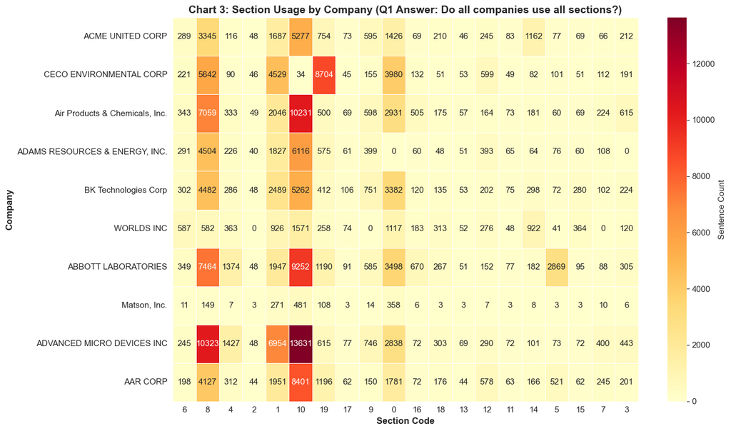

```python
# Cross-tab: Which companies use which sections?
section_company_cross = (
    df.group_by(["section", "name"])
    .agg(pl.count("sentence").alias("count"))
    .pivot(index="name", columns="section", values="count")
    .fill_null(0)
)

section_company_pd = section_company_cross.to_pandas().set_index('name')

# Heatmap
fig, ax = plt.subplots(figsize=(14, 8))
sns.heatmap(section_company_pd, annot=True, fmt='.0f', cmap='YlOrRd',
            linewidths=0.5, cbar_kws={'label': 'Sentence Count'}, ax=ax)
ax.set_title('Chart 3: Section Usage by Company (Q1 Answer: Do all companies use all sections?)',
             fontsize=14, fontweight='bold')
ax.set_xlabel('Section Code', fontsize=12, fontweight='bold')
ax.set_ylabel('Company', fontsize=12, fontweight='bold')
plt.tight_layout()
plt.show()
```

```
📊 Token Length Statistics:
   Mean: 25.8 tokens
   Median: 22 tokens
   95th percentile: 55 tokens
   Max: 737 tokens
```

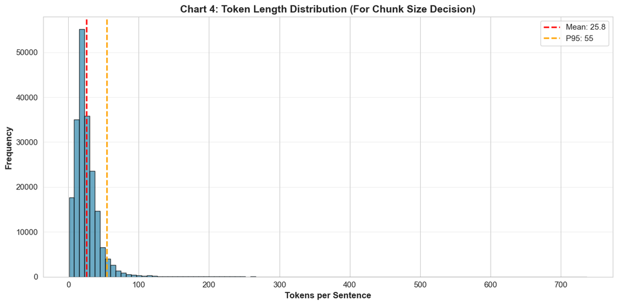

```
💡 Chunk Size Recommendation:
   3-sentence chunks: ~77 tokens (avg)
   5-sentence chunks: ~129 tokens (avg)
   Embedding limit (512 tokens): Fits ~19.9 sentences
```

```python
# Token length analysis (word-based tokenization)
import nltk
nltk.download('punkt', quiet=True)

# Calculate token counts
token_counts = df.with_columns([
    pl.col("sentence").str.split(" ").list.len().alias("token_count")
])

# Statistics
token_stats = token_counts.select([
    pl.col("token_count").mean().alias("mean"),
    pl.col("token_count").median().alias("median"),
    pl.col("token_count").quantile(0.95).alias("p95"),
    pl.col("token_count").max().alias("max"),
    pl.col("token_count").min().alias("min")
]).to_pandas()

print("📊 Token Length Statistics:")
print(f"   Mean: {token_stats['mean'][0]:.1f} tokens")
print(f"   Median: {token_stats['median'][0]:.0f} tokens")
print(f"   95th percentile: {token_stats['p95'][0]:.0f} tokens")
print(f"   Max: {token_stats['max'][0]:.0f} tokens")

# Histogram
fig, ax = plt.subplots(figsize=(12, 6))
token_data = token_counts.select("token_count").to_pandas()['token_count']

ax.hist(token_data, bins=100, color='#2E86AB', alpha=0.7, edgecolor='black')
ax.axvline(token_stats['mean'][0], color='red', linestyle='--', linewidth=2, label=f"Mean: {token_stats['mean'][0]:.1f}")
ax.axvline(token_stats['p95'][0], color='orange', linestyle='--', linewidth=2, label=f"P95: {token_stats['p95'][0]:.0f}")
ax.set_xlabel('Tokens per Sentence', fontsize=12, fontweight='bold')
ax.set_ylabel('Frequency', fontsize=12, fontweight='bold')
ax.set_title('Chart 4: Token Length Distribution (For Chunk Size Decision)', fontsize=14, fontweight='bold')
ax.legend()
ax.grid(axis='y', alpha=0.3)
plt.tight_layout()
plt.show()

# Chunk size recommendation
print(f"\n💡 Chunk Size Recommendation:")
print(f"   3-sentence chunks: ~{token_stats['mean'][0] * 3:.0f} tokens (avg)")
print(f"   5-sentence chunks: ~{token_stats['mean'][0] * 5:.0f} tokens (avg)")
print(f"   Embedding limit (512 tokens): Fits ~{512 / token_stats['mean'][0]:.1f} sentences")
```

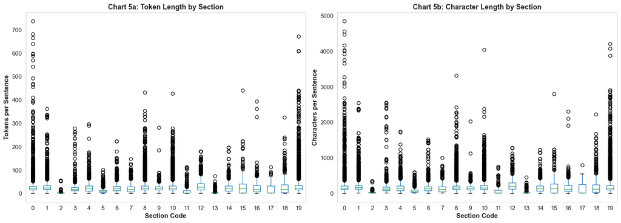

```python
# Text length by section
section_text_stats = df.with_columns([
    pl.col("sentence").str.len_chars().alias("char_count"),
    pl.col("sentence").str.split(" ").list.len().alias("token_count")
]).select(["section", "char_count", "token_count"])

section_text_pd = section_text_stats.to_pandas()

# Boxplot for token count by section
fig, axes = plt.subplots(1, 2, figsize=(16, 6))

# Token count boxplot
section_text_pd.boxplot(column='token_count', by='section', ax=axes[0], grid=False)
axes[0].set_xlabel('Section Code', fontsize=12, fontweight='bold')
axes[0].set_ylabel('Tokens per Sentence', fontsize=12, fontweight='bold')
axes[0].set_title('Chart 5a: Token Length by Section', fontsize=13, fontweight='bold')
axes[0].get_figure().suptitle('')  # Remove default title

# Char count boxplot
section_text_pd.boxplot(column='char_count', by='section', ax=axes[1], grid=False)
axes[1].set_xlabel('Section Code', fontsize=12, fontweight='bold')
axes[1].set_ylabel('Characters per Sentence', fontsize=12, fontweight='bold')
axes[1].set_title('Chart 5b: Character Length by Section', fontsize=13, fontweight='bold')
axes[1].get_figure().suptitle('')

plt.tight_layout()
plt.show()
```

```python
# Detailed stats by section
section_density = (
    df.with_columns([
        pl.col("sentence").str.len_chars().alias("char_count"),
        pl.col("sentence").str.split(" ").list.len().alias("token_count")
    ])
    .group_by("section")
    .agg([
        pl.col("char_count").mean().alias("avg_chars"),
        pl.col("token_count").mean().alias("avg_tokens"),
        pl.col("char_count").median().alias("median_chars"),
        pl.col("token_count").median().alias("median_tokens"),
        pl.col("char_count").max().alias("max_chars"),
        pl.col("token_count").max().alias("max_tokens"),
        pl.count("sentence").alias("sentence_count")
    ])
    .sort("section")
)

section_density_pd = section_density.to_pandas()
section_density_pd = section_density_pd.round(1)

display_table_with_html(
    section_density_pd,
    title="Table 6: Text Density by Section (Item 7 vs Item 1A Comparison)"
)

# Highlight extremes
densest_section = section_density_pd.loc[section_density_pd['avg_tokens'].idxmax(), 'section']
sparsest_section = section_density_pd.loc[section_density_pd['avg_tokens'].idxmin(), 'section']

print(f"\n🔍 Density Analysis:")
print(f"   Densest section: {densest_section} ({section_density_pd.loc[section_density_pd['avg_tokens'].idxmax(), 'avg_tokens']:.1f} avg tokens)")
print(f"   Sparsest section: {sparsest_section} ({section_density_pd.loc[section_density_pd['avg_tokens'].idxmin(), 'avg_tokens']:.1f} avg tokens)")
```

Table 6: Text Density by Section (Item 7 vs Item 1A Comparison)

|  | section | avg_chars | avg_tokens | median_chars | median_tokens | max_chars | max_tokens | sentence_count |
| --- | --- | --- | --- | --- | --- | --- | --- | --- |
| 0 | 0 | 174.2 | 25.4 | 145.0 | 21.0 | 4850 | 737 | 21311 |
| 1 | 1 | 182.5 | 27.7 | 160.0 | 24.0 | 2544 | 362 | 24627 |
| 2 | 2 | 27.6 | 4.5 | 8.0 | 2.0 | 342 | 55 | 374 |
| 3 | 3 | 140.4 | 20.7 | 116.0 | 18.0 | 2557 | 279 | 2317 |
| 4 | 4 | 152.0 | 23.6 | 131.0 | 21.0 | 1743 | 296 | 4534 |
| 5 | 5 | 74.6 | 11.6 | 68.0 | 10.0 | 596 | 101 | 3893 |
| 6 | 6 | 149.2 | 23.5 | 127.0 | 20.0 | 1515 | 223 | 2836 |
| 7 | 7 | 129.7 | 20.5 | 112.0 | 18.0 | 1002 | 147 | 1355 |
| 8 | 8 | 168.8 | 26.0 | 148.0 | 23.0 | 3317 | 433 | 47677 |
| 9 | 9 | 146.2 | 22.7 | 140.0 | 22.0 | 2031 | 281 | 3993 |
| 10 | 10 | 172.1 | 26.2 | 150.0 | 23.0 | 4045 | 428 | 60256 |
| 11 | 11 | 67.2 | 10.3 | 8.0 | 2.0 | 751 | 113 | 608 |
| 12 | 12 | 229.8 | 33.4 | 199.0 | 28.0 | 1273 | 179 | 2906 |
| 13 | 13 | 27.0 | 4.7 | 17.0 | 3.0 | 451 | 74 | 479 |
| 14 | 14 | 162.6 | 25.1 | 127.0 | 20.0 | 1223 | 197 | 3166 |
| 15 | 15 | 179.3 | 27.6 | 129.0 | 21.0 | 2800 | 440 | 1125 |
| 16 | 16 | 158.9 | 24.5 | 113.0 | 17.0 | 2298 | 394 | 1889 |
| 17 | 17 | 117.4 | 17.4 | 8.0 | 2.0 | 795 | 112 | 661 |
| 18 | 18 | 165.8 | 25.7 | 114.0 | 18.0 | 2222 | 325 | 1681 |
| 19 | 19 | 183.7 | 28.4 | 140.0 | 22.0 | 4214 | 672 | 14312 |

```
🔍 Density Analysis:
   Densest section: 12 (33.4 avg tokens)
   Sparsest section: 2 (4.5 avg tokens)
```

```python
# Identify extreme outliers (likely tables)
outliers = df.with_columns([
    pl.col("sentence").str.len_chars().alias("char_count")
]).filter(
    pl.col("char_count") > 1000  # Threshold for "table-like" text
).select(["section", "char_count", "sentence"]).head(5)

outliers_pd = outliers.to_pandas()

print("⚠️ Outlier Examples (Likely Tables/Lists):")
for idx, row in outliers_pd.iterrows():
    print(f"\n   Section {row['section']} | {row['char_count']} chars")
    print(f"   Preview: {row['sentence'][:150]}...")
```

```
⚠️ Outlier Examples (Likely Tables/Lists):

   Section 1 | 1174 chars
   Preview: Consequently, we are subject to a variety of risks that are specific to international operations, including the following: ●military conflicts, civil ...

   Section 10 | 1022 chars
   Preview: Sales by segment for these customers are as follows: AAR CORP. AND SUBSIDIARIES NOTES TO CONSOLIDATED FINANCIAL STATEMENTS (Continued) (Dollars in mil...

   Section 12 | 1040 chars
   Preview: The Company’s internal control over financial reporting is a process designed by, or under the supervision of, our Chief Executive Officer and Chief F...

   Section 19 | 1330 chars
   Preview: 4.3 Description of Capital Stock (filed herewith) 4.4 Rights Agreement, dated as of March 30, 2020, by and between AAR CORP. and Computershare Trust C...

   Section 19 | 1850 chars
   Preview: Material Contracts 10.1* Amended and Restated AAR CORP. Stock Benefit Plan effective October 1, 2001 (incorporated by reference to Exhibit 10.1 to the...
```